# Project 2: Investigation of the Gapminder World Database

- Introduction
- Data Wrangling
- Exploratory Data Analysis
- Conclusions

## Introduction

Gapminder is an independet Swedish foundation which dedicated itself to providing reliable statistics for almost every aspect of global development. They're self stated goal is to provide free to explore datasets for everybody to promota a better understanding of the world on a fact basis. Therefore, they collaborate with universities, the UN, NGOs and public agencies to gather reliable datasets and make them available to the public in one place.

For this project I chose to compare the economic and welfare development of different regions from different parts of the world. I chose to build a dataset based on the following measures:

**economic measure:**

- GDP per capita. It is calculated using the gross domestic product of country divided by its population. Aditionally, the values are adjusted for differences in purchasing power

**health related measures:**

- life expectancy: the life expectancy is defined as the average amount of years a newborn child is expected to live if current mortality patterns were to stay the same.
- child mortality: defined as the total amount of death of children under 5 years of age per 1000 live births.
- birth rate: defined as the average number of children to be born to a family.

The following packages are used to explore the dataset:

```python
import numpy as np
import pandas as pd
% matplotlib inline
import matplotlib.pyplot as plt
import seaborn as sns
from functools import reduce
from IPython.display import set_matplotlib_formats
from scipy.stats.stats import pearsonr
```

## Data Wrangling

### General Properties

To get started, I import all CSV files from gapminder which contain the data for this project and assign each one to a variable.

```python
gdp_per_cap = pd.read_csv('income_per_person_gdppercapita_ppp_inflation_adjusted.csv')
life_exp = pd.read_csv('life_expectancy_years.csv')
child_mortality = pd.read_csv('child_mortality_0_5_year_olds_dying_per_1000_born.csv')
birth_rate = pd.read_csv('children_per_woman_total_fertility.csv')
```

1. Let's have a closer look at the properties of each dataset

```python
gdp_per_cap.head(1)
```

|  | geo | 1800 | 1801 | 1802 | 1803 | 1804 | 1805 | 1806 | 1807 | 1808 | ... | 2009 | 2010 | 2011 | 2012 | 2013 | 2014 | 2015 | 2016 | 2017 | 2018 |
| --- | --- | --- | --- | --- | --- | --- | --- | --- | --- | --- | --- | --- | --- | --- | --- | --- | --- | --- | --- | --- | --- |
| 0 | Afghanistan | 603 | 603 | 603 | 603 | 603 | 603 | 603 | 603 | 603 | ... | 1530 | 1610 | 1660 | 1840 | 1810 | 1780 | 1750 | 1740 | 1800 | 1870 |

1 rows × 220 columns

```python
life_exp.head(1)
```

|  | geo | 1800 | 1801 | 1802 | 1803 | 1804 | 1805 | 1806 | 1807 | 1808 | ... | 2009 | 2010 | 2011 | 2012 | 2013 | 2014 | 2015 | 2016 | 2017 | 2018 |
| --- | --- | --- | --- | --- | --- | --- | --- | --- | --- | --- | --- | --- | --- | --- | --- | --- | --- | --- | --- | --- | --- |
| 0 | Afghanistan | 28.2 | 28.2 | 28.2 | 28.2 | 28.2 | 28.2 | 28.1 | 28.1 | 28.1 | ... | 55.7 | 56.2 | 56.7 | 57.2 | 57.7 | 57.8 | 57.9 | 58.0 | 58.4 | 58.7 |

1 rows × 220 columns

```python
child_mortality.head(1)
```

|  | geo | 1800 | 1801 | 1802 | 1803 | 1804 | 1805 | 1806 | 1807 | 1808 | ... | 2009 | 2010 | 2011 | 2012 | 2013 | 2014 | 2015 | 2016 | 2017 | 2018 |
| --- | --- | --- | --- | --- | --- | --- | --- | --- | --- | --- | --- | --- | --- | --- | --- | --- | --- | --- | --- | --- | --- |
| 0 | Afghanistan | 469.0 | 469.0 | 469.0 | 469.0 | 469.0 | 469.0 | 470.0 | 470.0 | 470.0 | ... | 94.1 | 90.2 | 86.4 | 82.8 | 79.3 | 76.1 | 73.2 | 70.4 | 68.2 | 65.9 |

1 rows × 220 columns

```python
birth_rate.head(1)
```

|  | geo | 1800 | 1801 | 1802 | 1803 | 1804 | 1805 | 1806 | 1807 | 1808 | ... | 2009 | 2010 | 2011 | 2012 | 2013 | 2014 | 2015 | 2016 | 2017 | 2018 |
| --- | --- | --- | --- | --- | --- | --- | --- | --- | --- | --- | --- | --- | --- | --- | --- | --- | --- | --- | --- | --- | --- |
| 0 | Afghanistan | 7.0 | 7.0 | 7.0 | 7.0 | 7.0 | 7.0 | 7.0 | 7.0 | 7.0 | ... | 6.04 | 5.82 | 5.6 | 5.38 | 5.17 | 4.98 | 4.8 | 4.64 | 4.48 | 4.33 |

1 rows × 220 columns

```python
gdp_per_cap.shape
```

```
(193, 220)
```

Looks like each dataset has one column with a list of all countries followed by one column for each year containing the respective measurements. In order to be able to compare the influence of the different measures, it is necessary to merge each individual dataset into one big dataset. In their current shape, this is not possible. I envision the columns of the merged dataset so look like this: {country, year, measure1, measure2,...}. To achieve this, it is necessary to group all years to one `year` column and all values to one `value` column.

1. Change properties of each dataset

Pandas `.melt()` function allows us to do exactly this.

Let's start with the gdp_per_cap dataset:

```python
gdp_per_cap = gdp_per_cap.melt(id_vars=['geo'], var_name='year', value_name='gdp_per_capita')
gdp_per_cap.head(2)
```

|  | geo | year | gdp_per_capita |
| --- | --- | --- | --- |
| 0 | Afghanistan | 1800 | 603 |
| 1 | Albania | 1800 | 667 |

```python
gdp_per_cap.tail(2)
```

|  | geo | year | gdp_per_capita |
| --- | --- | --- | --- |
| 42265 | Zambia | 2018 | 3870 |
| 42266 | Zimbabwe | 2018 | 1950 |

```python
gdp_per_cap.shape
```

```
(42267, 3)
```

Before using the `.melt()` function, the gdp_per_cap dataset had a shape of 193 rows and 220 columns. Now, the dataset consists of 42,267 rows and just 3 columns with each row containing a unique country-year-gdp combination.

Let's do the same for the other 3 datasets and assign a value name for each measure:

```python
life_exp = life_exp.melt(id_vars=['geo'], var_name='year', value_name='life_exp')
child_mortality = child_mortality.melt(id_vars=['geo'], var_name='year', value_name='child_mortality')
birth_rate = birth_rate.melt(id_vars=['geo'], var_name='year', value_name='birth_rate')
```

```python
life_exp.head(1)
```

|  | geo | year | life_exp |
| --- | --- | --- | --- |
| 0 | Afghanistan | 1800 | 28.2 |

```python
child_mortality.head(1)
```

|  | geo | year | child_mortality |
| --- | --- | --- | --- |
| 0 | Afghanistan | 1800 | 469.0 |

```python
birth_rate.head(1)
```

|  | geo | year | birth_rate |
| --- | --- | --- | --- |
| 0 | Afghanistan | 1800 | 7.0 |

Now the datasets for all 4 measures are in the desired shape. Aditionally, they all have common `geo` and `year` columns which will work as keys to join them on.

1. Merge Datasets

```python
# create a list containing all dataframes
measures = [gdp_per_cap, life_exp, child_mortality, birth_rate]

# merge them into one dataframe. the argument how=inner' ensures that the merged dataframe
# only contains countries for which data exists in all 4 datasets.
df = reduce(lambda left, right: pd.merge(left, right, how='inner', on=['geo', 'year']), measures)
```

(Disclaimer: I adapted the solution to merging multiple datasets at once from this stackoverflow post https://stackoverflow.com/questions/44327999/python-pandas-merge-multiple-dataframes)

```python
df.head(2)
```

|  | geo | year | gdp_per_capita | life_exp | child_mortality | birth_rate |
| --- | --- | --- | --- | --- | --- | --- |
| 0 | Afghanistan | 1800 | 603 | 28.2 | 469.0 | 7.0 |
| 1 | Albania | 1800 | 667 | 35.4 | 375.0 | 4.6 |

The result is a merged DataFrame `df` which now contains the information for all 4 measures.

Looks good so far, but I think `country` would be a more appropriate name for the `geo` column. So let's rename it:

```python
df.rename(columns={'geo': 'country'}, inplace=True)
df.head(0)
```

|  | country | year | gdp_per_capita | life_exp | child_mortality | birth_rate |
| --- | --- | --- | --- | --- | --- | --- |

Better.

How about checking how many different countries the merged DataFrame contains now.

```python
df['country'].nunique()
```

```
184
```

The DataFrame contains values for 184 different countries. Concidering the UN recognizes 195 different countries in total, this DataFrame makes an impressive basis to work with. But in order to later analyze regional differences and not just compare countries, it might actually make sense assign each country to its associating continent. In fact, this is exactly what we'll do now:

1. Assign each country to its associating continent

4.1. get list of unique countries in the DataFrame

```python
df['country'].unique()
```

```
array(['Afghanistan', 'Albania', 'Algeria', 'Angola',
       'Antigua and Barbuda', 'Argentina', 'Armenia', 'Australia',
       'Austria', 'Azerbaijan', 'Bahamas', 'Bahrain', 'Bangladesh',
       'Barbados', 'Belarus', 'Belgium', 'Belize', 'Benin', 'Bhutan',
       'Bolivia', 'Bosnia and Herzegovina', 'Botswana', 'Brazil',
       'Brunei', 'Bulgaria', 'Burkina Faso', 'Burundi', 'Cambodia',
       'Cameroon', 'Canada', 'Cape Verde', 'Central African Republic',
       'Chad', 'Chile', 'China', 'Colombia', 'Comoros',
       'Congo, Dem. Rep.', 'Congo, Rep.', 'Costa Rica', "Cote d'Ivoire",
       'Croatia', 'Cuba', 'Cyprus', 'Czech Republic', 'Denmark',
       'Djibouti', 'Dominican Republic', 'Ecuador', 'Egypt',
       'El Salvador', 'Equatorial Guinea', 'Eritrea', 'Estonia',
       'Ethiopia', 'Fiji', 'Finland', 'France', 'Gabon', 'Gambia',
       'Georgia', 'Germany', 'Ghana', 'Greece', 'Grenada', 'Guatemala',
       'Guinea', 'Guinea-Bissau', 'Guyana', 'Haiti', 'Honduras',
       'Hungary', 'Iceland', 'India', 'Indonesia', 'Iran', 'Iraq',
       'Ireland', 'Israel', 'Italy', 'Jamaica', 'Japan', 'Jordan',
       'Kazakhstan', 'Kenya', 'Kiribati', 'Kuwait', 'Kyrgyz Republic',
       'Lao', 'Latvia', 'Lebanon', 'Lesotho', 'Liberia', 'Libya',
       'Lithuania', 'Luxembourg', 'Macedonia, FYR', 'Madagascar',
       'Malawi', 'Malaysia', 'Maldives', 'Mali', 'Malta', 'Mauritania',
       'Mauritius', 'Mexico', 'Micronesia, Fed. Sts.', 'Moldova',
       'Mongolia', 'Montenegro', 'Morocco', 'Mozambique', 'Myanmar',
       'Namibia', 'Nepal', 'Netherlands', 'New Zealand', 'Nicaragua',
       'Niger', 'Nigeria', 'North Korea', 'Norway', 'Oman', 'Pakistan',
       'Palestine', 'Panama', 'Papua New Guinea', 'Paraguay', 'Peru',
       'Philippines', 'Poland', 'Portugal', 'Qatar', 'Romania', 'Russia',
       'Rwanda', 'Samoa', 'Sao Tome and Principe', 'Saudi Arabia',
       'Senegal', 'Serbia', 'Seychelles', 'Sierra Leone', 'Singapore',
       'Slovak Republic', 'Slovenia', 'Solomon Islands', 'Somalia',
       'South Africa', 'South Korea', 'South Sudan', 'Spain', 'Sri Lanka',
       'St. Lucia', 'St. Vincent and the Grenadines', 'Sudan', 'Suriname',
       'Swaziland', 'Sweden', 'Switzerland', 'Syria', 'Tajikistan',
       'Tanzania', 'Thailand', 'Timor-Leste', 'Togo', 'Tonga',
       'Trinidad and Tobago', 'Tunisia', 'Turkey', 'Turkmenistan',
       'Uganda', 'Ukraine', 'United Arab Emirates', 'United Kingdom',
       'United States', 'Uruguay', 'Uzbekistan', 'Vanuatu', 'Venezuela',
       'Vietnam', 'Yemen', 'Zambia', 'Zimbabwe'], dtype=object)
```

4.2 Assign each country to its associated continent

```python
europe = ['Albania', 'Austria', 'Azerbaijan', 'Belarus', 'Belgium', 'Bosnia and Herzegovina', 'Bulgaria', 'Croatia',
         'Cyprus', 'Czech Republic', 'Denmark', 'Estonia', 'Finland', 'France', 'Georgia', 'Germany', 'Greece',
         'Hungary', 'Iceland', 'Ireland', 'Italy', 'Latvia', 'Lithuania', 'Luxembourg', 'Macedonia, FYR',
         'Malta', 'Moldova', 'Montenegro', 'Netherlands', 'Norway', 'Poland', 'Portugal', 'Romania', 'Serbia',
         'Slovak Republic', 'Slovenia', 'Spain', 'Sweden', 'Switzerland', 'Turkey', 'Ukraine', 'United Kingdom']
africa = ['Algeria', 'Angola', 'Benin', 'Botswana', 'Burkina Faso', 'Burundi', 'Cameroon', 'Cape Verde',
          'Central African Republic', 'Chad', 'Comoros', 'Congo, Dem. Rep', 'Congo, Rep.', "Cote d'Ivoire",
          'Djibouti', 'Egypt', 'Equatorial Guinea', 'Eritrea', 'Ethiopia', 'Gabon', 'Gambia', 'Ghana', 'Guinea',
          'Guinea-Bissau', 'Kenya', 'Lesotho', 'Liberia', 'Libya', 'Madagascar', 'Malawi', 'Mali', 'Mauritania',
         'Mauritius', 'Morocco', 'Mozambique', 'Namibia', 'Niger', 'Nigeria', 'Rwanda', 'Sao Tome and Principe',
         'Senegal', 'Seychelles', 'Sierra Leone', 'Somalia', 'South Africa', 'South Sudan', 'Sudan', 'Suriname',
         'Swaziland', 'Syria', 'Tanzania', 'Togo', 'Tunisia', 'Uganda', 'Zambia', 'Zimbabwe']
asia = ['Afghanistan', 'Armenia', 'Bahrain', 'Bangladesh', 'Bhutan', 'Brunei', 'Cambodia', 'China', 'India',
       'Indonesia', 'Iran', 'Iraq', 'Israel', 'Japan', 'Jordan', 'Kazakhstan', 'Kuwait', 'Kyrgyz Republic', 'Lao',
       'Lebanon', 'Malaysia', 'Maldives', 'Mongolia', 'Myanmar', 'Nepal', 'North Korea', 'Oman', 'Pakistan',
       'Palestine', 'Philippines', 'Qatar', 'Russia', 'Saudi Arabia', 'Singapore', 'South Korea', 'Sri Lanka',
       'Tajikistan', 'Thailand', 'Turkmenistan', 'United Arab Emirates', 'Uzbekistan', 'Vietnam', 'Yemen']
ozeania = ['Australia', 'Kiribati', 'Micronesia, Fed. Sts.', 'New Zealand', 'Papua New Guinea', 'Samoa', 'Fiji',
          'Solomon Islands', 'Timor-Leste', 'Tonga', 'Vanuatu']
north_america = ['Antigua and Barbuda', 'Bahamas', 'Barbados', 'Belize', 'Canada', 'Dominican Republic', 'Grenada',
                'Guatemala', 'Haiti', 'Honduras', 'Jamaica', 'Nicaragua', 'St. Lucia', 'St. Vincent and the Grenadines',
                'United States']
south_america = ['Argentina', 'Bolivia', 'Brazil', 'Chile', 'Colombia', 'Costa Rica', 'Cuba', 'Ecuador', 'El Salvador',
                'Guyana', 'Mexico', 'Panama', 'Paraguay', 'Peru', 'Trinidad and Tobago', 'Uruguay', 'Venezuela']
```

4.3 Define a function which tells Pandas which value to assign to each country, depending on the continent.

```python
def assign_name(df):
    if df['country'] in europe:
        val = 'Europe'
    elif df['country'] in africa:
        val = 'Africa'
    elif df['country'] in asia:
        val = 'Asia'
    elif df['country'] in ozeania:
        val = 'Ozeania'
    elif df['country'] in north_america:
        val = 'North America'
    else:
        val = 'South America'
    return val
```

4.4 Finally, create a new column in the DataFrame containing each countrys respective continent.

```python
df['continent'] = df.apply(assign_name, axis=1)
df.head()
```

|  | country | year | gdp_per_capita | life_exp | child_mortality | birth_rate | continent |
| --- | --- | --- | --- | --- | --- | --- | --- |
| 0 | Afghanistan | 1800 | 603 | 28.2 | 469.0 | 7.00 | Asia |
| 1 | Albania | 1800 | 667 | 35.4 | 375.0 | 4.60 | Europe |
| 2 | Algeria | 1800 | 715 | 28.8 | 460.0 | 6.99 | Africa |
| 3 | Angola | 1800 | 618 | 27.0 | 486.0 | 6.93 | Africa |
| 4 | Antigua and Barbuda | 1800 | 757 | 33.5 | 474.0 | 5.00 | North America |

```python
df.tail(2)
```

|  | country | year | gdp_per_capita | life_exp | child_mortality | birth_rate | continent |
| --- | --- | --- | --- | --- | --- | --- | --- |
| 40294 | Zambia | 2018 | 3870 | 59.5 | 59.5 | 4.87 | Africa |
| 40295 | Zimbabwe | 2018 | 1950 | 60.2 | 55.5 | 3.61 | Africa |

Looks like step 4 worked and we now have a continent assigned to each row. This will benefit us greatly in the Exploratory Data Analysis later. Thus, it's time for step:

1. Inspect the DataFrame for flaws which need correction

```python
df.info()
```

```
<class 'pandas.core.frame.DataFrame'>
Int64Index: 40296 entries, 0 to 40295
Data columns (total 7 columns):
country            40296 non-null object
year               40296 non-null object
gdp_per_capita     40296 non-null int64
life_exp           40296 non-null float64
child_mortality    40294 non-null float64
birth_rate         40296 non-null float64
continent          40296 non-null object
dtypes: float64(3), int64(1), object(3)
memory usage: 2.5+ MB
```

```python
df.duplicated().sum()
```

```
0
```

```python
df.loc[df['child_mortality'].isnull()]
```

|  | country | year | gdp_per_capita | life_exp | child_mortality | birth_rate | continent |
| --- | --- | --- | --- | --- | --- | --- | --- |
| 39972 | Czech Republic | 2017 | 31700 | 79.2 | NaN | 1.56 | Europe |
| 40156 | Czech Republic | 2018 | 32300 | 79.4 | NaN | 1.57 | Europe |

Two odd things to note here. First, the data type of year is `object`. To later filter the dataset and have appropriate axis-labels, it might be useful to change it to `int`. Second, the `child_mortality` column contains missing values for Czech Republic for the years 2017 and 2018. So we also have to deal with those. But other than that, the DataFrame contains no duplicates and looks pretty clean.

### Data Cleaning

Let's correct the two flaws we discovered while inspecting the DataFrame

1. change data type of `year` column

```python
df['year'] = df['year'].astype(int)
df.info()
```

```
<class 'pandas.core.frame.DataFrame'>
Int64Index: 40296 entries, 0 to 40295
Data columns (total 7 columns):
country            40296 non-null object
year               40296 non-null int32
gdp_per_capita     40296 non-null int64
life_exp           40296 non-null float64
child_mortality    40294 non-null float64
birth_rate         40296 non-null float64
continent          40296 non-null object
dtypes: float64(3), int32(1), int64(1), object(2)
memory usage: 2.3+ MB
```

1. Deal with the missing values in the `child_mortality` column

   As there are only 2 values missing, it might be a good idea to have a look at the child mortality of the Czech Republic in the 5 years prior to the years with missing values. If they look like they remain at a constant level, we could calculate the mean value of the prior 5 years and then fill the missing values with the mean value.

```python
cz = df.query('country in "Czech Republic"').query('year >= 2012').query('year < 2017')
cz
```

|  | country | year | gdp_per_capita | life_exp | child_mortality | birth_rate | continent |
| --- | --- | --- | --- | --- | --- | --- | --- |
| 39052 | Czech Republic | 2012 | 28500 | 78.0 | 3.2 | 1.49 | Europe |
| 39236 | Czech Republic | 2013 | 28400 | 78.3 | 3.1 | 1.50 | Europe |
| 39420 | Czech Republic | 2014 | 29100 | 78.6 | 3.1 | 1.51 | Europe |
| 39604 | Czech Republic | 2015 | 30400 | 78.9 | 3.2 | 1.52 | Europe |
| 39788 | Czech Republic | 2016 | 31100 | 79.1 | 3.2 | 1.54 | Europe |

Looks like there has been no big change in child mortality in the Czech Republic in the years 2012 to 2016. So let's calculate the mean and assign it to the missing values for the years 2017 and 2018.

```python
cz['child_mortality'].mean()
```

```
3.16
```

```python
df['child_mortality'] = df['child_mortality'].fillna(3.16)
#check if worked
cz_filled = df.query('country in "Czech Republic"').query('year > 2016')
cz_filled
```

|  | country | year | gdp_per_capita | life_exp | child_mortality | birth_rate | continent |
| --- | --- | --- | --- | --- | --- | --- | --- |
| 39972 | Czech Republic | 2017 | 31700 | 79.2 | 3.16 | 1.56 | Europe |
| 40156 | Czech Republic | 2018 | 32300 | 79.4 | 3.16 | 1.57 | Europe |

```python
df.isnull().any().sum()
```

```
0
```

The DataFrame is now clean and we can move on the fun part of exploring it.

## Exploratory Data Analysis

First of all, let's get an insight to each variable by having a look at some 1-D properties:

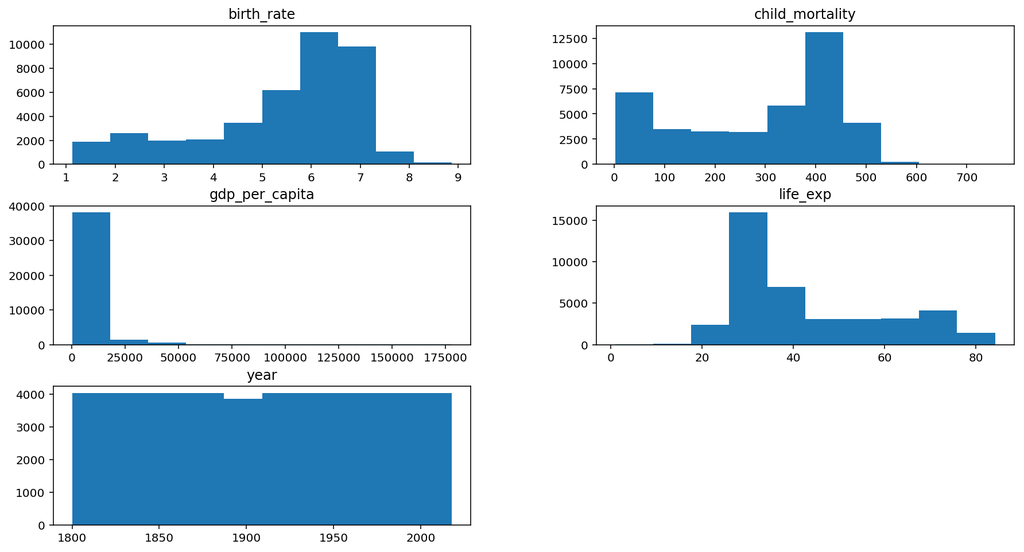

```python
set_matplotlib_formats('retina')
df.hist(figsize=(15,8), grid=False);
```

The birth rate variable seems skewed to the left. The child mortality variable is bi-modal with heights towards each end of the spectrum. The GDP per capita and life expectany variable both seem skewed to the right.

How about visualizing them in another way:

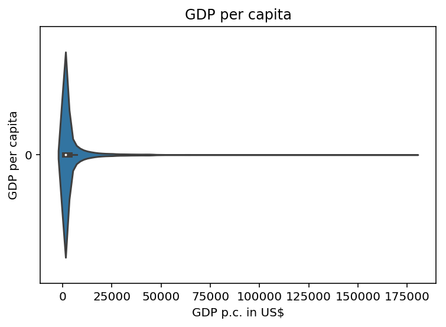

```python
sns.violinplot(data=df['gdp_per_capita'], orient='h')
plt.title('GDP per capita')
plt.xlabel('GDP p.c. in US$')
plt.ylabel('GDP per capita');
```

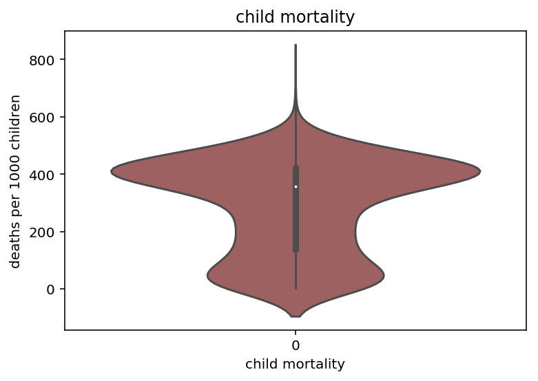

```python
sns.violinplot(data=df['child_mortality'], palette='Set1', saturation=.3, bw=.3)
plt.title('child mortality')
plt.xlabel('child mortality')
plt.ylabel('deaths per 1000 children');
```

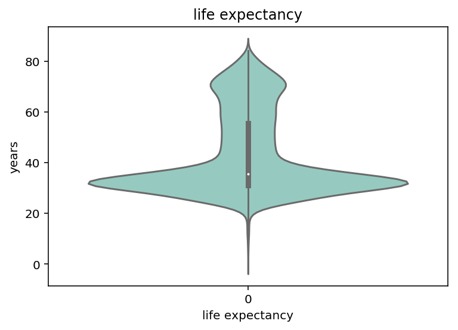

```python
sns.violinplot(data=df['life_exp'], palette='Set3', bw=.15)
plt.title('life expectancy')
plt.xlabel('life expectancy')
plt.ylabel('years');
```

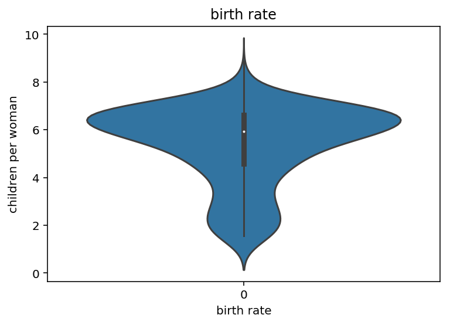

```python
sns.violinplot(data=df['birth_rate'], bw=.3)
plt.title('birth rate')
plt.xlabel('birth rate')
plt.ylabel('children per woman');
```

Now that we got a feel for each variable, let's move on to getting an insight to interesting questions:

### Research Question 1: Are there differences in the development of the GDP per capita across different continents?

To adress this question, we need to first assign a variable for each continent where we filter the DataFrame by the respective continent. We can do this using Pandas build in `.query()` function. On top of that, we need to group each query by year and calculate the mean value for each measure in each year. Long story short, the Code which does the job for me looks like this:

```python
europe_df = df.query('continent in "Europe"').groupby('year').mean().reset_index()
europe_df.head()
```

|  | year | gdp_per_capita | life_exp | child_mortality | birth_rate |
| --- | --- | --- | --- | --- | --- |
| 0 | 1800 | 1390.238095 | 35.454762 | 378.452381 | 5.478571 |
| 1 | 1801 | 1389.642857 | 35.435714 | 376.595238 | 5.467381 |
| 2 | 1802 | 1399.738095 | 35.514286 | 374.809524 | 5.484762 |
| 3 | 1803 | 1396.976190 | 34.954762 | 374.023810 | 5.482619 |
| 4 | 1804 | 1403.000000 | 35.297619 | 373.357143 | 5.486190 |

This DataFrame now contains the main value of all countries within Europe for each year. (The `.reset_index()` function is necessary to make it later easier to filter for certain years. Without `.reset_index()`, the `year` column would become the index which is something I don't want.)

Let's do the same for all other countries:

```python
north_america_df = df.query('continent in "North America"').groupby('year').mean().reset_index()
south_america_df = df.query('continent in "South America"').groupby('year').mean().reset_index()
africa_df = df.query('continent in "Africa"').groupby('year').mean().reset_index()
asia_df = df.query('continent in "Asia"').groupby('year').mean().reset_index()
ozeania_df = df.query('continent in "Ozeania"').groupby('year').mean().reset_index()
```

Now we can use matplotlib to create a visual and investigate differences in GDP per capita development.

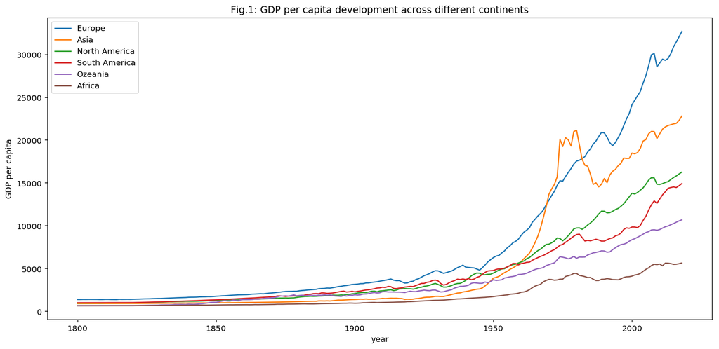

```python
set_matplotlib_formats('retina')
plt.figure(figsize=(15,7))
plt.plot(europe_df['year'], europe_df['gdp_per_capita'], label='Europe')
plt.plot(asia_df['year'], asia_df['gdp_per_capita'], label='Asia')
plt.plot(north_america_df['year'], north_america_df['gdp_per_capita'], label='North America')
plt.plot(south_america_df['year'], south_america_df['gdp_per_capita'], label='South America')
plt.plot(ozeania_df['year'], ozeania_df['gdp_per_capita'], label='Ozeania')
plt.plot(africa_df['year'], africa_df['gdp_per_capita'], label='Africa')
plt.legend()
plt.title('Fig.1: GDP per capita development across different continents')
plt.xlabel('year')
plt.ylabel('GDP per capita');
```

```python
gdp_per_cap_1900 = df.query('year == 1900')['gdp_per_capita']
print('mean GDP per capita in 1900: {}'.format(round(gdp_per_cap_1900.mean(), 2)))
print('standard deviation in 1900: {}'.format(round(gdp_per_cap_1900.std(), 2)))

gdp_per_cap_2018 = df.query('year == 2018')['gdp_per_capita']
print('mean GDP per capita in 2018: {}'.format(round(gdp_per_cap_2018.mean(), 2)))
print('standard deviation in 2018: {}'.format(round(gdp_per_cap_2018.std(), 2)))
```

```
mean GDP per capita in 1900: 1840.61
standard deviation in 1900: 1562.08
mean GDP per capita in 2018: 17919.24
standard deviation in 2018: 19595.64
```

The line graph shows that the GDP per capita was roughly the same for all continents in the 19th century. Only then do changes in economic growth start to kick in and from the 1950's onward, the economic growth is almost exponential for some continents. However, it has to be noted, that not all continents participated equally in economic growth and thus walfare inequalities worsend ever since the beginning of the 20th century. This becomes clear when comparing the global standard deviation in 1900 (1,562) and 2018 (19,595). Europe's economy is currenctly by far the strongest, followed by Asia and North America, Africa being the taillight. Also interesting to note is the fact, that the 3 wealthiest continents are all located North of the Equator, whereas the 3 poorest continents all have the majority of their landmass South of the Equator.

### Research Question 2: How does the development of continents compare regarding life expectancy?

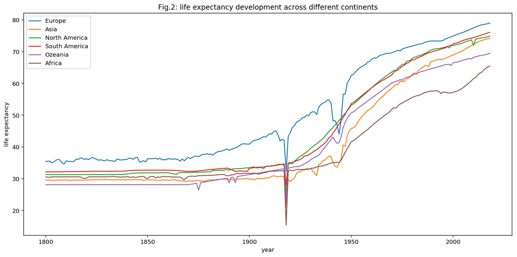

```python
set_matplotlib_formats('retina')
plt.figure(figsize=(15,7))
plt.plot(europe_df['year'], europe_df['life_exp'], label='Europe')
plt.plot(asia_df['year'], asia_df['life_exp'], label='Asia')
plt.plot(north_america_df['year'], north_america_df['life_exp'], label='North America')
plt.plot(south_america_df['year'], south_america_df['life_exp'], label='South America')
plt.plot(ozeania_df['year'], ozeania_df['life_exp'], label='Ozeania')
plt.plot(africa_df['year'], africa_df['life_exp'], label='Africa')
plt.legend()
plt.title('Fig.2: life expectancy development across different continents')
plt.xlabel('year')
plt.ylabel('life expectancy');
```

```python
life_exp_19th_century = df.query('year >= 1800').query('year < 1900')['life_exp']
print('Average life expectancy in 19th century: {} years'.format(round(life_exp_19th_century.mean(), 2)))

life_exp_21st_century = df.query('year >= 2000').query('year <=2018')['life_exp']
print('Average life expectancy in 21st century: {} years'.format(round(life_exp_21st_century.mean(), 2)))
```

```
Average life expectancy in 19th century: 31.94 years
Average life expectancy in 21st century: 69.93 years
```

Regarding the average life expectancy, each continent experienced an increase starting at the turn of the 19th century. Although there are differences among continents, the average life expectancy doubled for most continents compared to their value in the 19th century. The global mean life expectancy was just 31.9 years int the 19th century and the global average is currently 69.9 years for the 21st century.

(Side note: Clearly visible are also two major dips resulting in the millions of casualties during the course of WW1 and WW2.)

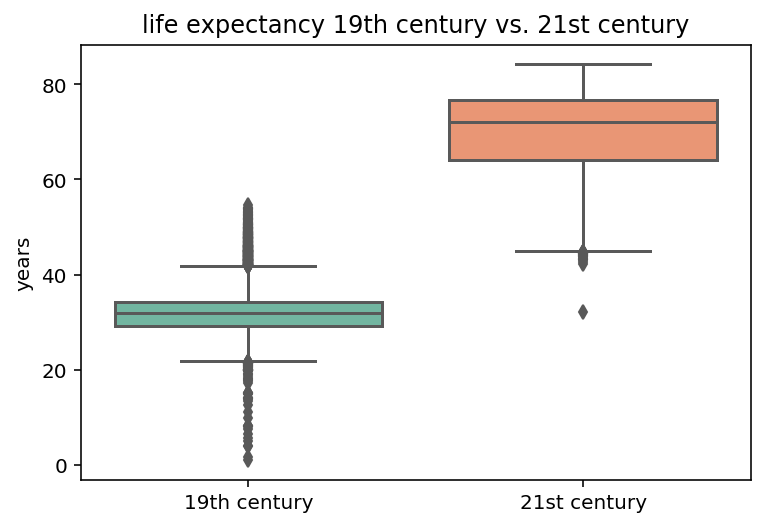

```python
# put both life expectancy variables in a list to compare visually
life_exp_comparison = [life_exp_19th_century, life_exp_21st_century]

# create visual
N = 2 # number of elements to compare
ind = np.arange(N) # location for xticks

sns.boxplot(data=life_exp_comparison, palette='Set2')
plt.title('life expectancy 19th century vs. 21st century')
plt.ylabel('years')
plt.xticks(ind, ['19th century', '21st century']);
```

This visual also highlights the improvement in life expectancy over the course of the 20th century.

### Research Question 3: How does the average child mortality evolve over time across different continents

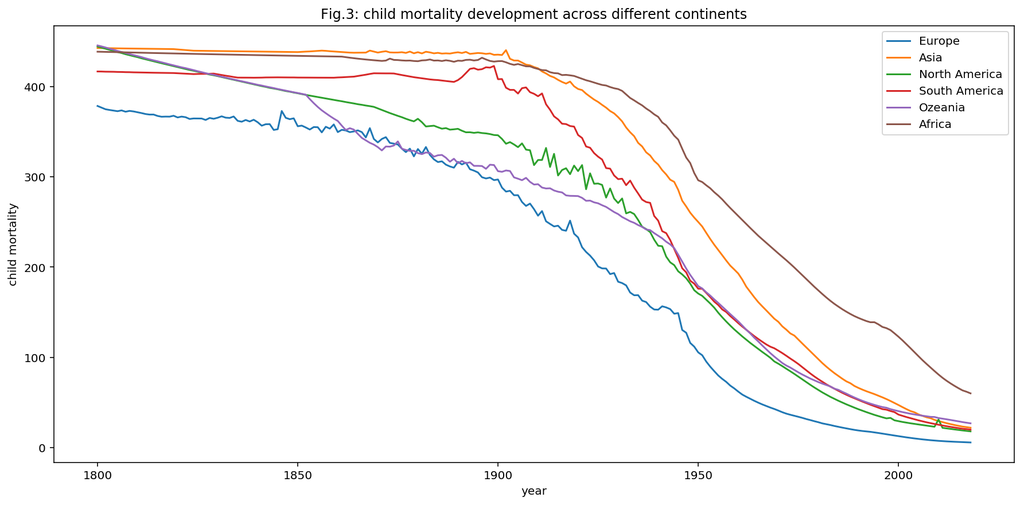

```python
set_matplotlib_formats('retina')
plt.figure(figsize=(15,7))
plt.plot(europe_df['year'], europe_df['child_mortality'], label='Europe')
plt.plot(asia_df['year'], asia_df['child_mortality'], label='Asia')
plt.plot(north_america_df['year'], north_america_df['child_mortality'], label='North America')
plt.plot(south_america_df['year'], south_america_df['child_mortality'], label='South America')
plt.plot(ozeania_df['year'], ozeania_df['child_mortality'], label='Ozeania')
plt.plot(africa_df['year'], africa_df['child_mortality'], label='Africa')
plt.legend()
plt.title('Fig.3: child mortality development across different continents')
plt.xlabel('year')
plt.ylabel('child mortality');
```

```python
child_mortality_1800 = df.query('year == 1800')['child_mortality']
print('Average child mortality per 1000 children in 1800: {}'.format(round(child_mortality_1800.mean(), 1)))

child_mortality_2018 = df.query('year == 2018')['child_mortality']
print('Average child mortality per 1000 children in 2018: {}'.format(round(child_mortality_2018.mean(), 1)))
```

```
Average child mortality per 1000 children in 1800: 424.5
Average child mortality per 1000 children in 2018: 29.3
```

In contrast to the figures 1 and 2, the average child mortality decreases for all continents with the year variable increasing. The average child mortaility rate was 425 in 1800, meaning 42% of all live born children did not make it past age 5. This number decreased to a global average of just 2.9% in 2018.

One more visual to showcase the development:

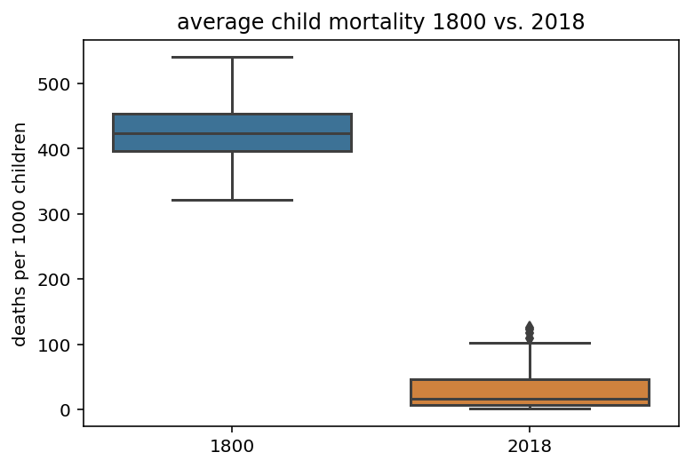

```python
# create list of elements to compare
child_mortality_comparison = [child_mortality_1800, child_mortality_2018]

N = 2 # number of elements to compare
ind = np.arange(N) # locations for xticks

# create visual
sns.boxplot(data=child_mortality_comparison, saturation=.6)
plt.title('average child mortality 1800 vs. 2018')
plt.ylabel('deaths per 1000 children')
plt.xticks(ind, ['1800', '2018']);
```

Now clearly visible is a major decrease in the child mortality rate over the course of the past 200 years.

### Research Question 4: How does the average birth rate between different continents compare over time?

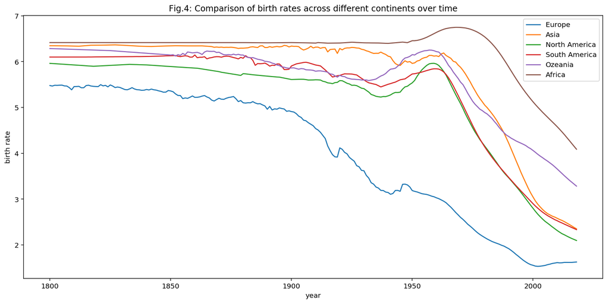

```python
set_matplotlib_formats('retina')
plt.figure(figsize=(15,7))
plt.plot(europe_df['year'], europe_df['birth_rate'], label='Europe')
plt.plot(asia_df['year'], asia_df['birth_rate'], label='Asia')
plt.plot(north_america_df['year'], north_america_df['birth_rate'], label='North America')
plt.plot(south_america_df['year'], south_america_df['birth_rate'], label='South America')
plt.plot(ozeania_df['year'], ozeania_df['birth_rate'], label='Ozeania')
plt.plot(africa_df['year'], africa_df['birth_rate'], label='Africa')
plt.legend()
plt.title('Fig.4: Comparison of birth rates across different continents over time')
plt.xlabel('year')
plt.ylabel('birth rate');
```

```python
birth_rates_1800 = df.query('year == 1800')['birth_rate']
print('mean birth rate in 1800: {} children per woman'.format(round(birth_rates_1800.mean(), 2)))
print('standard deviation in 1800: {}'.format(round(birth_rates_1800.std(), 2)))

birth_rates_2018 = df.query('year == 2018')['birth_rate']
print('mean birth rate in 2018: {} children per woman'.format(round(birth_rates_2018.mean(), 2)))
print('standard deviation in 2018: {}'.format(round(birth_rates_2018.std(), 2)))
```

```
mean birth rate in 1800: 6.11 children per woman
standard deviation in 1800: 0.79
mean birth rate in 2018: 2.74 children per woman
standard deviation in 2018: 1.29
```

### Research Question 5: How do birth rates compare in 2018 across different continents?

1. Assign a variable for each continent which contains the birth rates in 2018 in the continent

```python
birth_rates_europe_2018 = df.query('year == 2018').query('continent == "Europe"')['birth_rate']
birth_rates_africa_2018 = df.query('year == 2018').query('continent == "Africa"')['birth_rate']
birth_rates_asia_2018 = df.query('year == 2018').query('continent == "Asia"')['birth_rate']
birth_rates_north_america_2018 = df.query('year == 2018').query('continent == "North America"')['birth_rate']
birth_rates_south_america_2018 = df.query('year == 2018').query('continent == "South America"')['birth_rate']
birth_rates_ozeania_2018 = df.query('year == 2018').query('continent == "Ozeania"')['birth_rate']
```

1. Create visual

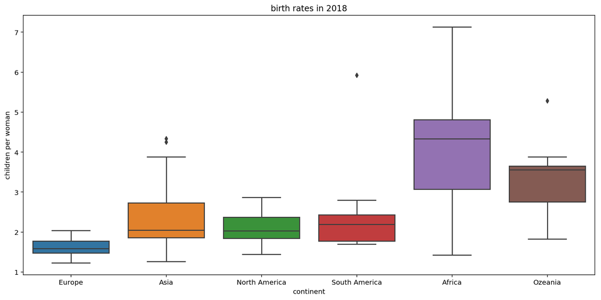

```python
# create list of datasets to compare
birth_rates_comparison = [birth_rates_europe_2018, birth_rates_asia_2018, birth_rates_north_america_2018,
                          birth_rates_south_america_2018, birth_rates_africa_2018, birth_rates_ozeania_2018]

N = 6 # number of datasets to compare
ind = np.arange(N) # location for xticks

# create visual
plt.figure(figsize=(15,7))
sns.boxplot(data=birth_rates_comparison)
plt.title('birth rates in 2018')
plt.ylabel('children per woman')
plt.xlabel('continent')
plt.xticks(ind, ['Europe', 'Asia', 'North America', 'South America', 'Africa', 'Ozeania']);
```

The boxplot shows the average birth rates in 2018 across different continents. Europe currently has the lowest birth rate. Asia, North America and South America are almost on the same level. Africa and Ozeania have the highest birth rates. The spread is quite high for Africa, indicating major differences in birth rates among countries within Africa.

### Reseach Question 6: Is there a correlation between the GDP per capita and life expectancy?

life expectancy is the dependent variable whereas GDP per capita is the independent variable

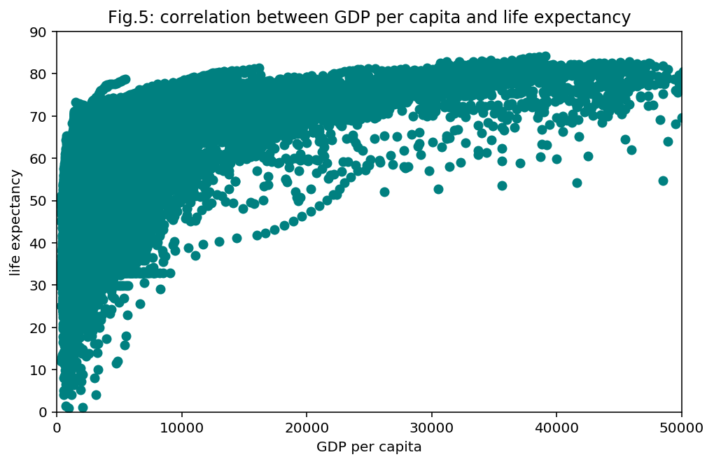

```python
set_matplotlib_formats('retina')
plt.figure(figsize=(8,5))
plt.scatter(df['gdp_per_capita'], df['life_exp'], color='teal')
plt.title('Fig.5: correlation between GDP per capita and life expectancy')
plt.xlabel('GDP per capita')
plt.ylabel('life expectancy')
plt.axis([0, 50000, 0, 90]);
```

```python
pearsonr(df['gdp_per_capita'], df['life_exp'])
```

```
(0.5731051857092431, 0.0)
```

The first number of the output is the pearson correlation coefficient. The correlation coefficient (0.57) is moderate and thus indicates a moderate probability for a positive correlation between the GDP per capita and the life expectancy. However, this does not mean, that an increase in one variable definately results in an increase in the other variable as one or both variables could be biased by a, yet unknown, third variable.

### Research Question 7: Is there a correlation between life expectancy and child mortality?

Life expectancy and child mortality are both variables which by common sense should depend on the same thing - the access to medication and improvement of hygienic conditions. The average child mortality can therefore be expected to decrease as the life expectancy increases. Let's have a closer look at both variables to examine this hypothesis.

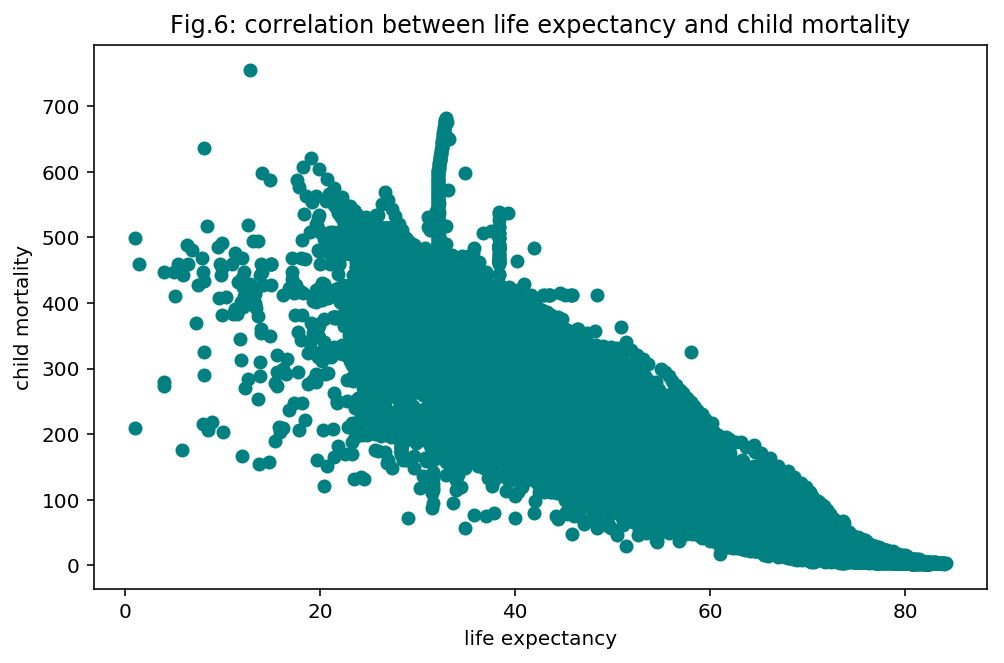

```python
set_matplotlib_formats('retina')
plt.figure(figsize=(8,5))
plt.scatter(df['life_exp'], df['child_mortality'], color='teal')
plt.title('Fig.6: correlation between life expectancy and child mortality')
plt.xlabel('life expectancy')
plt.ylabel('child mortality');
```

And indeed, from a pure visual investigation, a negative correlation seems to be obvious. Maybe the pearson correlation coefficient can confirm this obseration.

```python
pearsonr(df['life_exp'], df['child_mortality'])
```

```
(-0.9417413485419234, 0.0)
```

The pearson correlation coefficient is -0.94, thus indicating a high probability for a negative correlation between both variables. Although again, it has to be stated, that the pure calculation of a correlation coefficient is no sufficient proof of causation as one or both variables could be biased by a third, yet unknown, variable.

## Conclusion

To summarize, this report explored the development of economic and health related variales between 1800 and 2018. Furthermore, correlation among these variables was explored.

Regarding the development of the GDP per capita, things started out on a rather similar level in 1800 with huge differences emerging from the beginning of the 20th century. The average life expectancy doubled for each continent over the past 200 years but differences among continents are also present. The average child mortality and birth rate both decreased over time with the difference of this development starting roughly half a century earlier for child mortality.